# tppp1

[figure not shown]

## Exercice 1: On considère le polynôme $p(x) = (x - 1)^6$. En développant on peut écrire ce même polynôme sous la forme $f(x) = x^6 - 6x^5 + 15x^4 - 20x^3 + 15x^2 - 6x + 1.$ 1) Avec Matlab évaluer $p(x)$ et $f(x)$ pour $x$ allant de $.998$ à $1.002$ en choisissant des pas de $.0001$. 2) Faire un graphique de $f(x)$ et $p(x)$. Commenter.

```python
def p(x):
    ''' p(x)=(x-1)⁶'''
    return (x-1)**6 # ** puissance
def f(x):
    '''version développer de f(x)'''
    return x**6 - 6*x**5 + 15*x**4 - 20*x**3 + 15*x**2 - 6*x + 1
```

```python
# le calcul de p1(0.998)
print('p({})={} '.format(0.998,p(0.998)))
# le calcul de p2(0.998)
print('f({})={} '.format(0.998,f(0.998)))
```

```
p(0.998)=6.400000000000034e-17
f(0.998)=1.7763568394002505e-15
```

f(3)

#### 2)

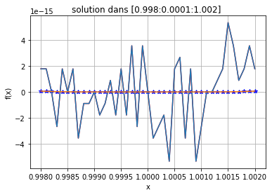

```python
import matplotlib.pyplot as plt
from numpy import linspace
x=linspace(0.998,1.002,41)
plt.plot(x,f(x),'r',x,p(x),'b*')
plt.title ("solution dans [0.998:0.0001:1.002] ");
plt.xlabel ("x");
plt.ylabel ("f(x)");
plt.grid(True)
plt.plot(x,f(x))
plt.plot(x,p(x))
```

## Expliquer ces sources d'erreurs !!!!

Les sources d erreurs est a partir du calcule de l ordinateur avec des petits valeur d erreur plusieurs fois ce qui rendre l erreur tres grands

# EXERCICE 2:

> On considère l'équation : $$ f(x)=x^3+x^2-3x-3=0$$ 1) Dessiner la courbe de $f$ dans l'intervalle $[-2;2]$, puis trouver des intervalles convenables pour appliquer la méthode de >bisection.

> 2) Utiliser un programme `dicho.m` qui permettra de trouver les solutions de l'équation $f(x)=0$ avec $eps=0.001$.

> 3) Modifier le programme `dicho.m` pour qu'il donne le nombre d'itération nécessaire pour avoir la solution à $eps$ près.

```python
T=[-2,0.1,2];
TT=linspace(-2,2,41);# subdivision de [-2,2] en 40 subdivision ( 41 ponts)
```

## Version Python

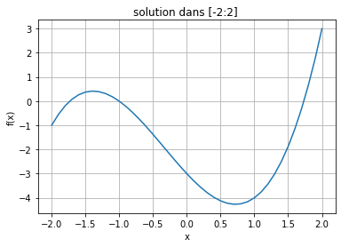

```python
import matplotlib.pyplot as plt
from numpy import linspace
f=lambda x: x**3+x**2-3*x-3
T=linspace(-2,2,41)
plt.title("solution dans [-2:2] ");
plt.xlabel("x")
plt.ylabel ("f(x)")
plt.grid(True)
plt.plot(T,f(T))
```

# Daprés le graph de $f$ il existe 3 solutions :

- $\alpha_1 \in ]-2;-1.5[$
- $\alpha_2 \in ]-1.5;-0.5[$
- $\alpha_3 \in ]1.5;2[$

### 2.2

`[x]=dicho(f,-2,-1.5,0.001)`

`[x]=diho(f,-2,-1.5,0.001)`

`[x]=dicho(f,-2,-1.5,0.001)`

### Donner la version python de `dicho`

```python
import matplotlib . pyplot as plt
import numpy as np
def dicho(a,b,f,n):
    m=(a+b)/2
    while  abs(b-a) > n :
        m = ( a + b ) / 2
        if f ( m ) == 0:
            return m
        elif f ( a ) * f ( m ) < 0:
            b = m
        else :
            a = m
    return (a+b)/2


    '''version itérative '''
    pass
```

```python
x3=dicho(-2,-1.5,f,10)
#x10=dicho(-2,-1.5,f,10)
#x20=dicho(-2,-1.5,f,20)
#print(x3,x10,x20)
print(x3)
```

```
-1.75
```

```python
x3=dicho(-2,-1.5,f,10)
x10=dicho(-2,-1.5,f,10)
x20=dicho(-2,-1.5,f,20)
print(x3,x10,x20)
print(x3)
```

```
-1.75 -1.75 -1.75
-1.75
```

```python
print('f(x10)={},f(x20)={}'.format(f(x10),f(x20)))
```

```
f(x10)=-0.046875,f(x20)=-0.046875
```

```python
def dichow(a,b,f,eps):
    m=(a+b)/2
    err=abs(b-a)
    ND=0
    while err>eps:
        ND += 1
        if f(m)==0:
            return m
        elif f(a)*f(m)<0:
            b=m
        else:
            a=m
        m = (a + b)/2
        err=abs(b-a)
    print (" nombre d'itérations nécessaires :", ND )
    return m
    pass
```

```python
dichow(-2,-1.5,f,0.0001)
```

```
 nombre d'itérations nécessaires : 13
```

```
-1.732025146484375
```

## 3

```python
import numpy as np
np.floor(2.3)
np.ceil(2.3)
```

```
3.0
```

```python
import numpy as np
a=-1.5
b=-0.5
p=8 # précision à 10 ^-8 prés
dichow(a,b,f,10**(-p))
#à 10^-8
```

```
-1.0
```

```python
interval=[[-2,-1.5],[-1.5,-0.5],[1.5,2]]
for u in interval:
    print(dichow(u[0],u[1],f,10**(-3)))
################################################
print(dichow(-2,-1.5,f,10**(-3)))
print(dichow(-1.5,-0.5,f,10**(-3)))
print(dichow(1.5,2,f,10**(-3)))
```

```
 nombre d'itérations nécessaires : 9
-1.73193359375
-1.0
 nombre d'itérations nécessaires : 9
1.73193359375
 nombre d'itérations nécessaires : 9
-1.73193359375
-1.0
 nombre d'itérations nécessaires : 9
1.73193359375
```

Le nombre d'itération N nécéssaire à la méthode de la dichotomie pour trouver $\alpha$ à $10^{-p}$ prés

$$N \geq E\left(\dfrac{\ln(b-a)+p\ln(10)}{\ln(2)}\right)+1$$

```python
## Ecrire une fonction qui permet de renvoyer le nombre d'itération nécessaire à la méthode de dichotomie pour calculer
## la solution à 10^-p près
#ND=lambda p:...............
def dichow(a,b,f,eps):
    m=(a+b)/2
    err=abs(b-a)
    ND=0
    while err>eps:
        ND += 1
        if f(m)==0:
            return m
        elif f(a)*f(m)<0:
            b=m
        else:
            a=m
        m = (a + b)/2
        err=abs(b-a)
    print (" nombre d'itérations nécessaires :", ND )
    return m
    pass
f=lambda x:x**3+x**2-3*x-3
```

```python
a=-2
b=-1.5
ND(5)
```

[output not shown]

```python
#alpha 1
dichow(-2,-1.5,f,10**(-5))
#à 10^-8
```

```
 nombre d'itérations nécessaires : 16
```

```
-1.7320518493652344
```

```python
#alpha 2
dichow(-1.51,-0.5,f,10**(-5))
#à 10^-8
```

```
 nombre d'itérations nécessaires : 17
```

```
-1.0000028610229492
```

## Méthode graphique pour la recherche de la solution

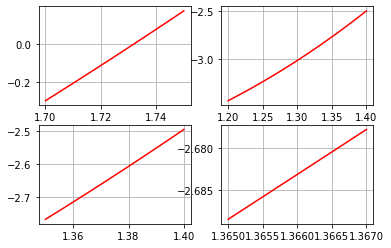

```python
%matplotlib inline
#import mpld3
#mpld3.enable_notebook()
import numpy as np
import matplotlib.pyplot as plt

f=lambda x:x**3+x**2-3*x-3

t=np.linspace(1.7,1.75,100)
plt.subplot(2,2,1)
plt.plot(t,f(t),'r')
plt.grid(True)
##########################################
t=np.linspace(1.2,1.4,100)
plt.subplot(2,2,2)
plt.plot(t,f(t),'r')
plt.grid(True)
##########################################
t=np.linspace(1.35,1.4,100)
plt.subplot(2,2,3)
plt.plot(t,f(t),'r')
plt.grid(True)
#########################################
t=np.linspace(1.365,1.367,100)
plt.subplot(2,2,4)
plt.plot(t,f(t),'r')
plt.grid(True)
```

## Transformer le code précédent pour trouver desvaleurs approchées des solutions $\alpha_1$, $\alpha_2$ et $\alpha_3$ de l'equation (E)